```r
PCAxform <- function(df, z=TRUE) {
  #' Obtain the dataframe with the Principal Components after the rotation.
  #' ELo 201911 GWU DATS
  #' @param df The dataframe.
  #' @param z T/F or 0/1 for z-score to be used
  #' @return The transformed dataframe.
  #' @examples
  #' tmp = PCAxform(USArrests,TRUE)

  z = ifelse(z==TRUE || z=="true" || z=="True" || z=="T" || z=="t" || z==1 || z=="1", TRUE, FALSE) # standardize z
  if(z) { df = data.frame(scale(df))}  # scale not safe for non-numeric colunms, but PCA requires all variables numerics to begin with.
  pr.out = prcomp(df,scale=z)
  df1 = data.frame( as.matrix(df) %*% pr.out$rotation ) # use matrix multiplication in R:  %*%
  return(df1)
}
# Sample
# USArrests.z.pc = PCAxform(USArrests,TRUE)
# summary(USArrests.z.pc)

PCRxform <- function(df, y, zX=TRUE, zy=FALSE) {
  #' Obtain the dataframe with the Principal Components after the rotation for PCRegression. Requires related function PCAxform()
  #' ELo 201903 GWU DATS
  #' @param df The dataframe.
  #' @param y The y-variable column index number(int), or the name of y-variable
  #' @param zX T/F or 0/1 for z-score used on X-variables
  #' @param zy T/F or 0/1 for z-score used on the target y-variable
  #' @return The transformed dataframe.
  #' @examples
  #' tmp = PCAxform(USArrests,TRUE)

  # take care of y target
  zy = ifelse(zy==TRUE || zy=="true" || zy=="True" || zy=="T" || zy=="t" || zy==1 || zy=="1", TRUE, FALSE) # standardize target y
  if( is.integer(y) ) { # y is integer
    if( y>length(df) || y<1 ) {
      print("Invalid column number")
      return(NULL)
    }
    if(zy) { df1 = data.frame( scale(df[y]) ) } else { df1 = df[y] } # save y-var in df1
    df = df[-y] # remove y-variable in df
  } else { # y is not integer, so interpret as name
    if(zy) { df1 = data.frame( scale( df[names(df) == y] ) ) } else { df1 = df[names(df) == y] }
    df = df[names(df) != y] # remove y-variable in df
  }
  if( length(df1)<1 ) {
    print("Variable name not found in data.frame")
    return(NULL)
  }
  # now transform X-vars
  zX = ifelse(zX==TRUE || zX=="true" || zX=="True" || zX=="T" || zX=="t" || zX==1 || zX=="1", TRUE, FALSE) # standardize X-vars
  df2 = PCAxform(df,zX)
  df1 = data.frame(df1,df2) # piece them back together
  return(df1)
}
```

```r
loadPkg(xtable)
loadPkg(kableExtra)
loadPkg(stringi)

xkabledply = function(modelsmmrytable, title="Table", digits = 4, pos="left", bso="striped") {
  modelsmmrytable %>%
    xtable() %>%
    kable(caption = title, digits = digits) %>%
    kable_styling(bootstrap_options = bso, full_width = FALSE, position = pos)
}

xkablesummary = function(df, title="Table: Statistics summary.", digits = 4, pos="left", bso="striped") {
  s = summary(df) %>%
    apply( 2, function(x) stringr::str_remove_all(x,c("Min.\\s*:\\s*","1st Qu.\\s*:\\s*","Median\\s*:\\s*","Mean\\s*:\\s*","3rd Qu.\\s*:\\s*","Max.\\s*:\\s*")) ) %>% # replace all leading words
    apply( 2, function(x) stringr::str_trim(x, "right")) # trim trailing spaces left

  colnames(s) <- stringr::str_trim(colnames(s))

  if ( dim(s)[1] ==6 ) { rownames(s) <- c('Min','Q1','Median','Mean','Q3','Max')
  } else if ( dim(s)[1] ==7 ) { rownames(s) <- c('Min','Q1','Median','Mean','Q3','Max','NA') }

  xkabledply(s, title=title, digits = digits, pos=pos, bso=bso )
}

xkablevif = function(model, title="VIFs of the model", digits = 3, pos="left", bso="striped") {
  vifs = table( names(model$coefficients)[2:length(model$coefficients)] ) # remove intercept to set column names
  vifs[] = faraway::vif(model) # set the values
  xkabledply( vifs, title=title, digits = digits, pos=pos, bso=bso )
}
```

```r
loadPkg('reshape2')
loadPkg('GGally')
loadPkg('ggplot2')
```

```r
library(readr)
library(ggplot2)
library(dplyr)
library(corrplot)
library(tidyr)
library(rworldmap)
library(classInt)
library(RColorBrewer)
library(ggrepel)
library(ggthemes)
library(scales)
library(data.table)
library(formattable)
library(plotly)
library(corrplot)
library(caret)
library(car)
```

### Internet Movie Database (IMDB) Dataset

Prelude:

What makes movies good or bad? Is it our emotional response towards them? Is it the critical reviews or the scores? Is it the association of popular directors or actors? Is it the amount they gross at the box office? What is it really that describes their success or failure? I have pondered over such questions many a times but never really got around to acknowledge them. Thus, when this project came along, I used it as an opportunity to try to find some answers this time around.Dataset can be downloaded here: https://data.world/data-society/imdb-5000-movie-dataset

# Dataset Structure

```r
movies <- read_csv("movie_metadata.csv")
str(movies)
```

```
## Classes 'spec_tbl_df', 'tbl_df', 'tbl' and 'data.frame': 5043 obs. of  28 variables:
##  $ color                    : chr  "Color" "Color" "Color" "Color" ...
##  $ director_name            : chr  "James Cameron" "Gore Verbinski" "Sam Mendes" "Christopher Nolan" ...
##  $ num_critic_for_reviews   : num  723 302 602 813 NA 462 392 324 635 375 ...
##  $ duration                 : num  178 169 148 164 NA 132 156 100 141 153 ...
##  $ director_facebook_likes  : num  0 563 0 22000 131 475 0 15 0 282 ...
##  $ actor_3_facebook_likes   : num  855 1000 161 23000 NA 530 4000 284 19000 10000 ...
##  $ actor_2_name             : chr  "Joel David Moore" "Orlando Bloom" "Rory Kinnear" "Christian Bale" ...
##  $ actor_1_facebook_likes   : num  1000 40000 11000 27000 131 640 24000 799 26000 25000 ...
##  $ gross                    : num  7.61e+08 3.09e+08 2.00e+08 4.48e+08 NA ...
##  $ genres                   : chr  "Action|Adventure|Fantasy|Sci-Fi" "Action|Adventure|Fantasy" "Action|Adventure|Thriller" "Action|Thriller" ...
##  $ actor_1_name             : chr  "CCH Pounder" "Johnny Depp" "Christoph Waltz" "Tom Hardy" ...
##  $ movie_title              : chr  "Avatar " "Pirates of the Caribbean: At World's End " "Spectre " "The Dark Knight Rises " ...
##  $ num_voted_users          : num  886204 471220 275868 1144337 8 ...
##  $ cast_total_facebook_likes: num  4834 48350 11700 106759 143 ...
##  $ actor_3_name             : chr  "Wes Studi" "Jack Davenport" "Stephanie Sigman" "Joseph Gordon-Levitt" ...
##  $ facenumber_in_poster     : num  0 0 1 0 0 1 0 1 4 3 ...
##  $ plot_keywords            : chr  "avatar|future|marine|native|paraplegic" "goddess|marriage ceremony|marriage proposal|pirate|singapore" "bomb|espionage|sequel|spy|terrorist" "deception|imprisonment|lawlessness|police officer|terrorist plot" ...
##  $ movie_imdb_link          : chr  "http://www.imdb.com/title/tt0499549/?ref_=fn_tt_tt_1" "http://www.imdb.com/title/tt0449088/?ref_=fn_tt_tt_1" "http://www.imdb.com/title/tt2379713/?ref_=fn_tt_tt_1" "http://www.imdb.com/title/tt1345836/?ref_=fn_tt_tt_1" ...
##  $ num_user_for_reviews     : num  3054 1238 994 2701 NA ...
##  $ language                 : chr  "English" "English" "English" "English" ...
##  $ country                  : chr  "USA" "USA" "UK" "USA" ...
##  $ content_rating           : chr  "PG-13" "PG-13" "PG-13" "PG-13" ...
##  $ budget                   : num  2.37e+08 3.00e+08 2.45e+08 2.50e+08 NA ...
##  $ title_year               : num  2009 2007 2015 2012 NA ...
##  $ actor_2_facebook_likes   : num  936 5000 393 23000 12 632 11000 553 21000 11000 ...
##  $ imdb_score               : num  7.9 7.1 6.8 8.5 7.1 6.6 6.2 7.8 7.5 7.5 ...
##  $ aspect_ratio             : num  1.78 2.35 2.35 2.35 NA 2.35 2.35 1.85 2.35 2.35 ...
##  $ movie_facebook_likes     : num  33000 0 85000 164000 0 24000 0 29000 118000 10000 ...
##  - attr(*, "spec")=
##   .. cols(
##   ..   color = col_character(),
##   ..   director_name = col_character(),
##   ..   num_critic_for_reviews = col_double(),
##   ..   duration = col_double(),
##   ..   director_facebook_likes = col_double(),
##   ..   actor_3_facebook_likes = col_double(),
##   ..   actor_2_name = col_character(),
##   ..   actor_1_facebook_likes = col_double(),
##   ..   gross = col_double(),
##   ..   genres = col_character(),
##   ..   actor_1_name = col_character(),
##   ..   movie_title = col_character(),
##   ..   num_voted_users = col_double(),
##   ..   cast_total_facebook_likes = col_double(),
##   ..   actor_3_name = col_character(),
##   ..   facenumber_in_poster = col_double(),
##   ..   plot_keywords = col_character(),
##   ..   movie_imdb_link = col_character(),
##   ..   num_user_for_reviews = col_double(),
##   ..   language = col_character(),
##   ..   country = col_character(),
##   ..   content_rating = col_character(),
##   ..   budget = col_double(),
##   ..   title_year = col_double(),
##   ..   actor_2_facebook_likes = col_double(),
##   ..   imdb_score = col_double(),
##   ..   aspect_ratio = col_double(),
##   ..   movie_facebook_likes = col_double()
##   .. )
```

# Data cleansing

Missing Values

```r
#Checking missing values
sum(is.na(movies))
```

```
## [1] 2698
```

```r
colSums(is.na(movies))
```

```
##                     color             director_name    num_critic_for_reviews
##                        19                       104                        50
##                  duration   director_facebook_likes    actor_3_facebook_likes
##                        15                       104                        23
##              actor_2_name    actor_1_facebook_likes                     gross
##                        13                         7                       884
##                    genres              actor_1_name               movie_title
##                         0                         7                         0
##           num_voted_users cast_total_facebook_likes              actor_3_name
##                         0                         0                        23
##      facenumber_in_poster             plot_keywords           movie_imdb_link
##                        13                       153                         0
##      num_user_for_reviews                  language                   country
##                        21                        12                         5
##            content_rating                    budget                title_year
##                       303                       492                       108
##    actor_2_facebook_likes                imdb_score              aspect_ratio
##                        13                         0                       329
##      movie_facebook_likes
##                         0
```

Proportion of Missing Values

```r
#Lot of missing values
mean(is.na(movies))
```

```
## [1] 0.0191
```

Discard Missing Values

```r
#Missing values are not in large proportion, so we can discard them without any fear.
movies <- na.omit(movies)
```

**Summary**

```r
xkablesummary(movies)
```

Table: Statistics summary.

|  | color | director_name | num_critic_for_reviews | duration | director_facebook_likes | actor_3_facebook_likes | actor_2_name | actor_1_facebook_likes | gross | genres | actor_1_name | movie_title | num_voted_users | cast_total_facebook_likes | actor_3_name | facenumber_in_poster | plot_keywords | movie_imdb_link | num_user_for_reviews | language | country | content_rating | budget | title_year | actor_2_facebook_likes | imdb_score | aspect_ratio | movie_facebook_likes |
| --- | --- | --- | --- | --- | --- | --- | --- | --- | --- | --- | --- | --- | --- | --- | --- | --- | --- | --- | --- | --- | --- | --- | --- | --- | --- | --- | --- | --- |
| Min | Length:3756 | Length:3756 | 2 | 37 | 0 | 0 | Length:3756 | 0 | 1.62e+02 | Length:3756 | Length:3756 | Length:3756 | 91 | 0 | Length:3756 | 0.0 | Length:3756 | Length:3756 | 4 | Length:3756 | Length:3756 | Length:3756 | 2.18e+02 | 1927 | 0 | 1.60 | 1.18 | 0 |
| Q1 | Class :character | Class :character | 77 | 96 | 11 | 194 | Class :character | 745 | 8.27e+06 | Class :character | Class :character | Class :character | 19667 | 1920 | Class :character | 0.0 | Class :character | Class :character | 110 | Class :character | Class :character | Class :character | 1.00e+07 | 1999 | 385 | 5.90 | 1.85 | 0 |
| Median | Mode :character | Mode :character | 138 | 106 | 64 | 436 | Mode :character | 1000 | 3.01e+07 | Mode :character | Mode :character | Mode :character | 53974 | 4060 | Mode :character | 1.0 | Mode :character | Mode :character | 210 | Mode :character | Mode :character | Mode :character | 2.50e+07 | 2004 | 686 | 6.60 | 2.35 | 227 |
| Mean | NA | NA | 167 | 110 | 807 | 771 | NA | 7751 | 5.26e+07 | NA | NA | NA | 105827 | 11527 | NA | 1.4 | NA | NA | 337 | NA | NA | NA | 4.62e+07 | 2003 | 2022 | 6.47 | 2.11 | 9354 |
| Q3 | NA | NA | 224 | 120 | 235 | 691 | NA | 13000 | 6.69e+07 | NA | NA | NA | 128602 | 16240 | NA | 2.0 | NA | NA | 398 | NA | NA | NA | 5.00e+07 | 2010 | 976 | 7.20 | 2.35 | 11000 |
| Max | NA | NA | 813 | 330 | 23000 | 23000 | NA | 640000 | 7.61e+08 | NA | NA | NA | 1689764 | 656730 | NA | 43.0 | NA | NA | 5060 | NA | NA | NA | 1.22e+10 | 2016 | 137000 | 9.30 | 16.00 | 349000 |

**Removed Columns Based on Nearzerovariance**

```r
#We find that colour and language are 2 such nearzero variables, so we exclude them during our prediction process.
#before any prediction, we should do exploratory analysis and visualisations.
nearZeroVar(movies, saveMetrics = T)
```

```
##                           freqRatio percentUnique zeroVar   nzv
## color                         29.29        0.0532   FALSE  TRUE
## director_name                  1.32       44.1693   FALSE FALSE
## num_critic_for_reviews         1.26       13.9776   FALSE FALSE
## duration                       1.09        4.0202   FALSE FALSE
## director_facebook_likes       16.05       10.5165   FALSE FALSE
## actor_3_facebook_likes         4.14       23.4824   FALSE FALSE
## actor_2_name                   1.43       58.2535   FALSE FALSE
## actor_1_facebook_likes         1.83       18.9830   FALSE FALSE
## gross                          1.33       44.9947   FALSE FALSE
## genres                         1.04       19.8349   FALSE FALSE
## actor_1_name                   1.08       38.0192   FALSE FALSE
## movie_title                    1.00       97.3110   FALSE FALSE
## num_voted_users                1.50       97.8168   FALSE FALSE
## cast_total_facebook_likes      1.00       86.3419   FALSE FALSE
## actor_3_name                   1.14       68.8765   FALSE FALSE
## facenumber_in_poster           1.66        0.5059   FALSE FALSE
## plot_keywords                  1.00       97.3376   FALSE FALSE
## movie_imdb_link                1.00       97.3376   FALSE FALSE
## num_user_for_reviews           1.06       25.0266   FALSE FALSE
## language                     105.82        0.9052   FALSE  TRUE
## country                        9.39        1.1981   FALSE FALSE
## content_rating                 1.30        0.3195   FALSE FALSE
## budget                         1.17        9.3450   FALSE FALSE
## title_year                     1.01        1.9702   FALSE FALSE
## actor_2_facebook_likes         2.60       22.7636   FALSE FALSE
## imdb_score                     1.09        1.9702   FALSE FALSE
## aspect_ratio                   1.25        0.4792   FALSE FALSE
## movie_facebook_likes          20.74       17.4920   FALSE FALSE
```

```r
table(movies$color)
```

```
##
## Black and White           Color
##             124            3632
```

```r
table(movies$language)
```

```
##
## Aboriginal     Arabic    Aramaic    Bosnian  Cantonese      Czech     Danish
##          2          1          1          1          7          1          3
##       Dari      Dutch    English   Filipino     French     German     Hebrew
##          2          3       3598          1         34         10          1
##      Hindi  Hungarian Indonesian    Italian   Japanese     Kazakh     Korean
##          5          1          2          7         10          1          5
##   Mandarin       Maya  Mongolian       None  Norwegian    Persian Portuguese
##         15          1          1          1          4          3          5
##   Romanian    Russian    Spanish       Thai Vietnamese       Zulu
##          1          1         23          3          1          1
```

### Exploratory Data Analysis

**Univariate analysis** *Pair plots 1*

[figure not shown]

```r
library(ggplot2)
library(GGally)
#Dataframe without character and factor features for prediction.
movies_df <- movies[, c(3, 4, 5, 6, 8, 9, 13, 14, 16, 19, 23, 24, 25, 26, 27, 28)]

ggpairs(movies_df, diag = list(continuous = "density", discrete = "bar"), axisLabels = "internal")
```

*Pair plots 2*

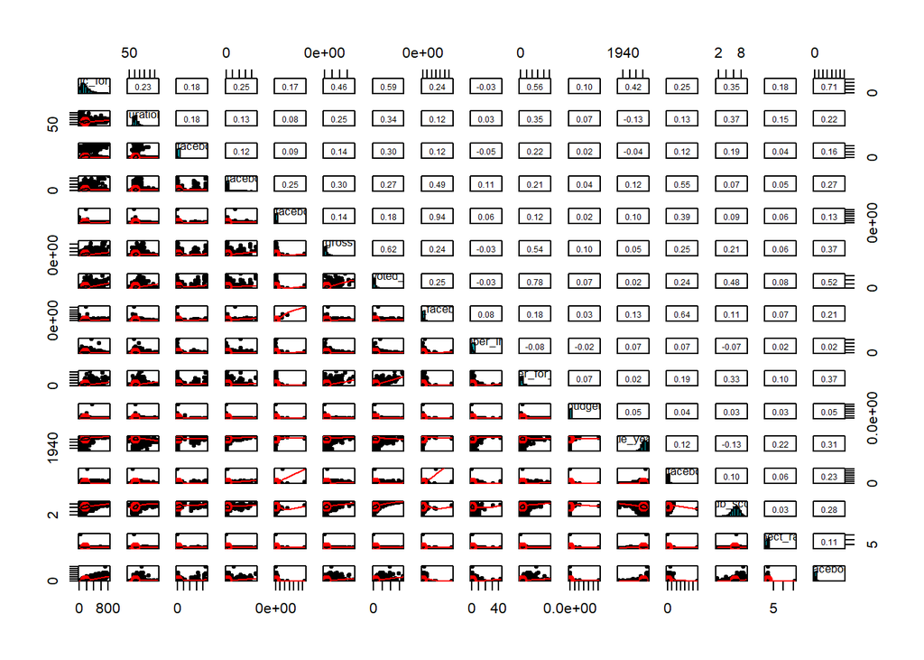

```r
loadPkg(psych)
loadPkg('dplyr')
pairs.panels(movies_df,
             method = "pearson", # correlation method
             hist.col = "#00AFBB", # set histogram color, can use "#22AFBB", "red",
             density = TRUE,  # show density plots
             ellipses = TRUE # show correlation ellipses
             )
```

```r
unloadPkg(psych)
```

**Scatter Plots** *IMDB_score v/s critic_reviews**

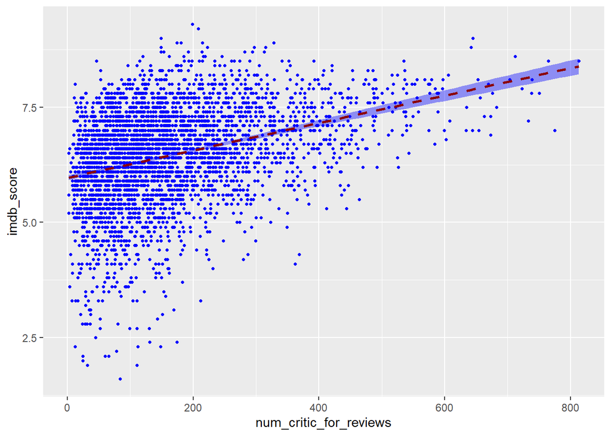

```r
ggplot(data = movies, aes( x= num_critic_for_reviews, y = imdb_score)) +
  geom_point(shape =20, color = "blue" ) +
  geom_smooth(method=lm,  linetype="dashed",
             color="darkred", fill="blue")
```

```r
  labs (title="Scatter Plot of Critic_Reviews and IMDB_Score",
        x="Critic Reviews",
        y = "IMDB_Score")
```

```
## $x
## [1] "Critic Reviews"
##
## $y
## [1] "IMDB_Score"
##
## $title
## [1] "Scatter Plot of Critic_Reviews and IMDB_Score"
##
## attr(,"class")
## [1] "labels"
```

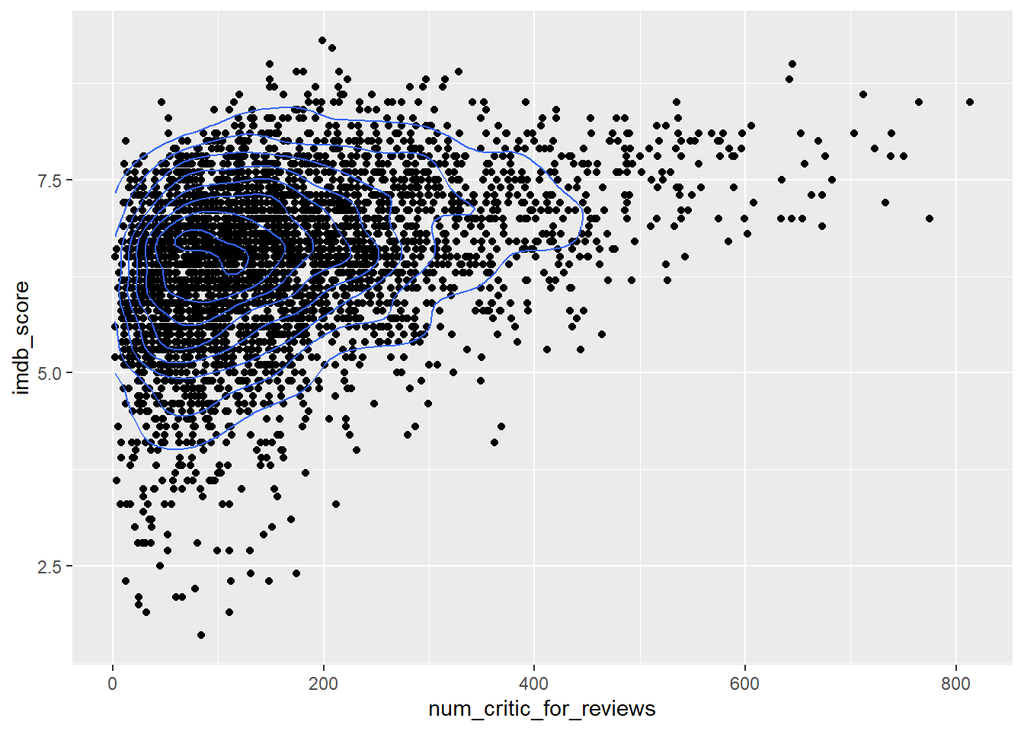

```r
  sp <-ggplot(data = movies, aes( x= num_critic_for_reviews, y = imdb_score)) +
  geom_point()
  sp+geom_density_2d()
```

*IMDB_score v/s Voted_users*

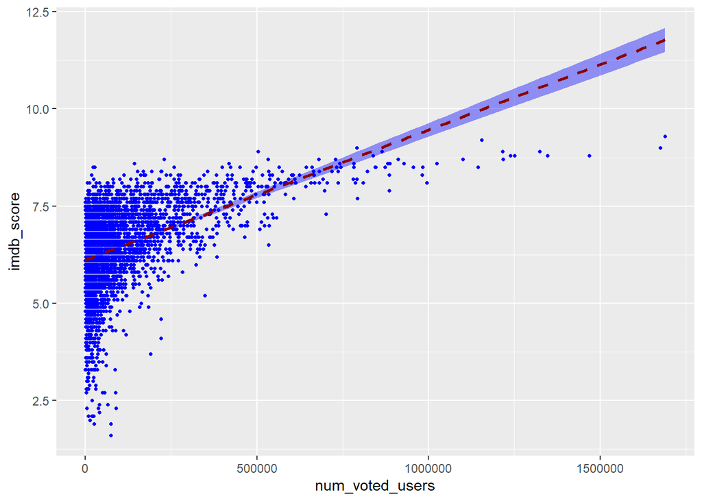

```r
ggplot(data = movies, aes( x= num_voted_users, y = imdb_score))+
  geom_point(shape = 20, color = "blue") +
  geom_smooth(method = lm, linetype="dashed",
             color="darkred", fill="blue")
```

```r
  labs (title="Scatter Plot of Critic_Reviews and IMDB_Score",
        x="Critic Reviews",
        y = "IMDB_Score")
```

```
## $x
## [1] "Critic Reviews"
##
## $y
## [1] "IMDB_Score"
##
## $title
## [1] "Scatter Plot of Critic_Reviews and IMDB_Score"
##
## attr(,"class")
## [1] "labels"
```

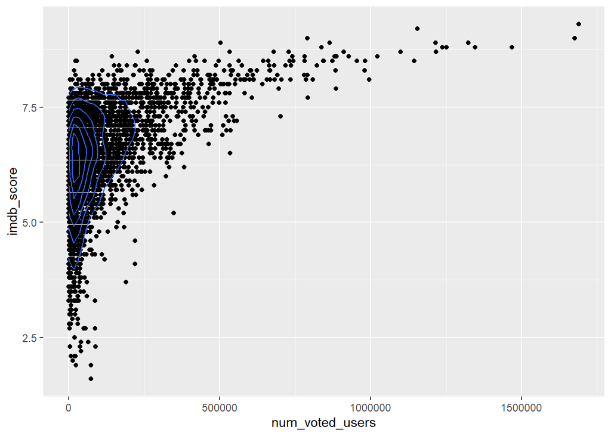

```r
sp <- ggplot(data = movies, aes( x= num_voted_users, y = imdb_score))  +
  geom_point()
  sp+geom_density_2d()
```

```r
#sp + stat_density_2d(aes(fill = ..level..), geom="polygon")
#sp + stat_density_2d(aes(fill = ..level..), geom="polygon")+
  #scale_fill_gradient(low="blue", high="red")
```

*IMDB_score v/s User_reviews*

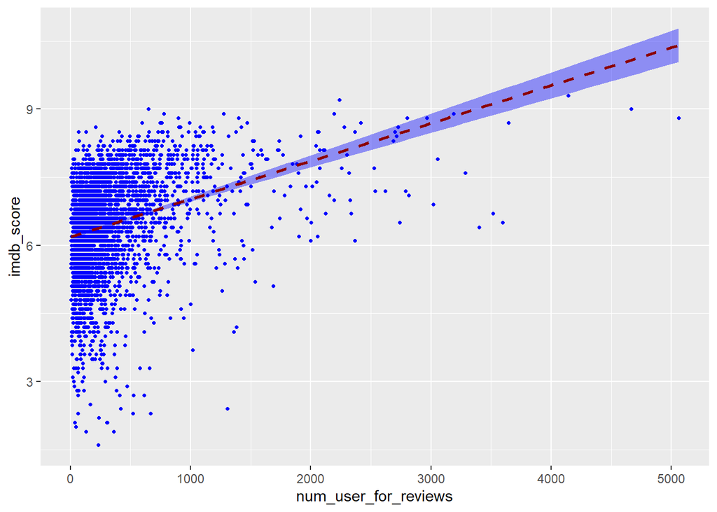

```r
ggplot(data = movies, aes( x= num_user_for_reviews, y = imdb_score)) +
  geom_point(shape =20, color = "blue" ) +
  geom_smooth(method=lm,  linetype="dashed",
             color="darkred", fill="blue")
```

```r
  labs (title="Scatter Plot of Actor and IMDB_Score",
        x="User_reviews",
        y = "IMDB_Score")
```

```
## $x
## [1] "User_reviews"
##
## $y
## [1] "IMDB_Score"
##
## $title
## [1] "Scatter Plot of Actor and IMDB_Score"
##
## attr(,"class")
## [1] "labels"
```

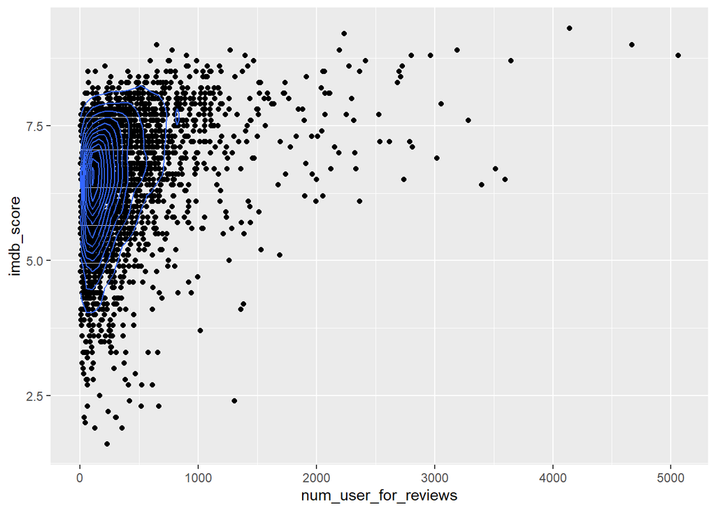

```r
sp <-ggplot(data = movies, aes( x= num_user_for_reviews, y = imdb_score)) +
geom_point()
  sp+geom_density_2d()
```

*IMDB_score v/s Movie_facebook_likes*

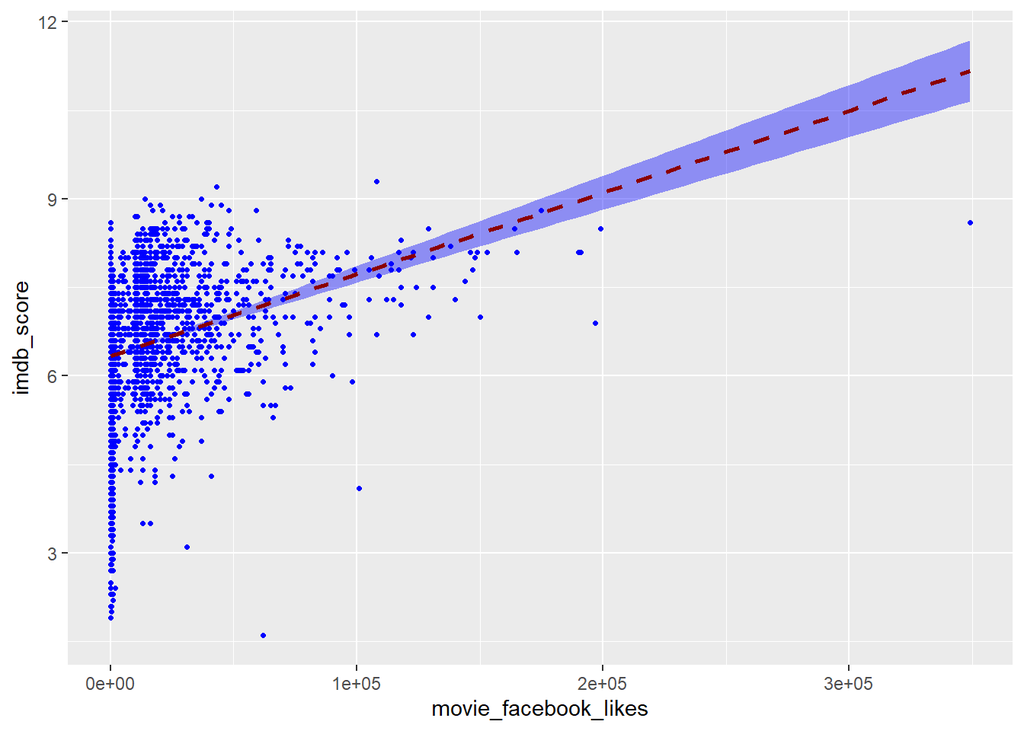

```r
ggplot(data = movies, aes( x= movie_facebook_likes, y = imdb_score)) +
  geom_point(shape =20, color = "blue" ) +
  geom_smooth(method=lm,  linetype="dashed",
             color="darkred", fill="blue")
```

```r
  labs (title="Scatter Plot of Actor and IMDB_Score",
        x="Movie FB likes",
        y = "IMDB_Score")
```

```
## $x
## [1] "Movie FB likes"
##
## $y
## [1] "IMDB_Score"
##
## $title
## [1] "Scatter Plot of Actor and IMDB_Score"
##
## attr(,"class")
## [1] "labels"
```

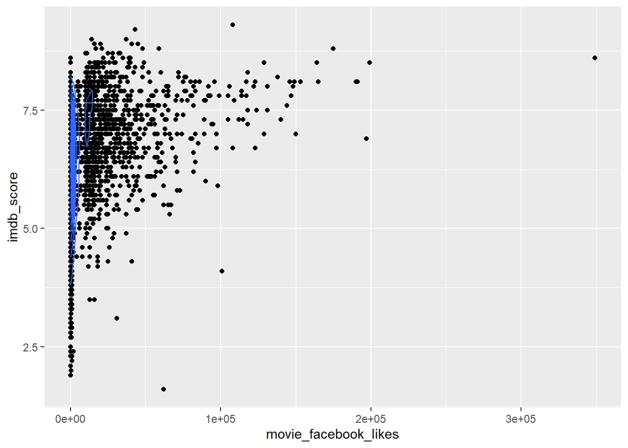

```r
sp <-ggplot(data = movies, aes( x= movie_facebook_likes, y = imdb_score)) +
geom_point()
  sp+geom_density_2d()
```

**Histograms**

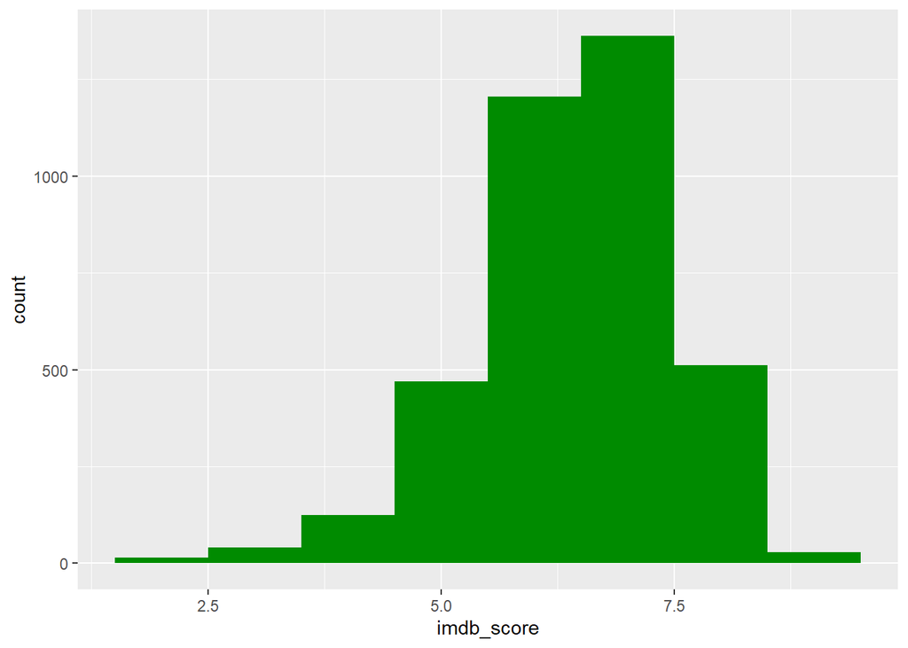

```r
ggplot(movies,aes(x=imdb_score))+
  geom_histogram(binwidth=1,aes(y=..count..),fill="green4")
```

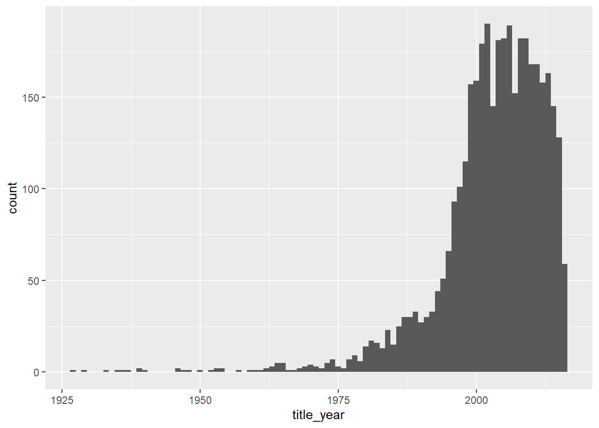

```r
ggplot(data=movies,aes(x = title_year))+geom_histogram(binwidth=1)
```

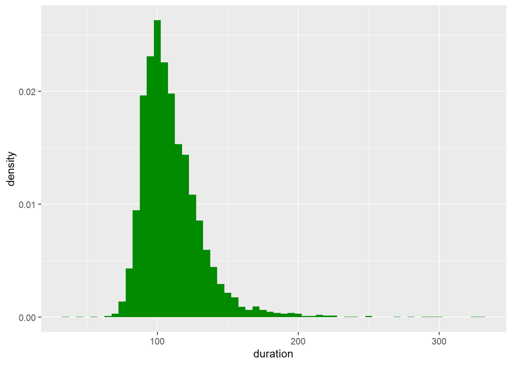

```r
ggplot(movies,aes(x=duration))+
  geom_histogram(binwidth=5,aes(y=..density..),fill="green4")
```

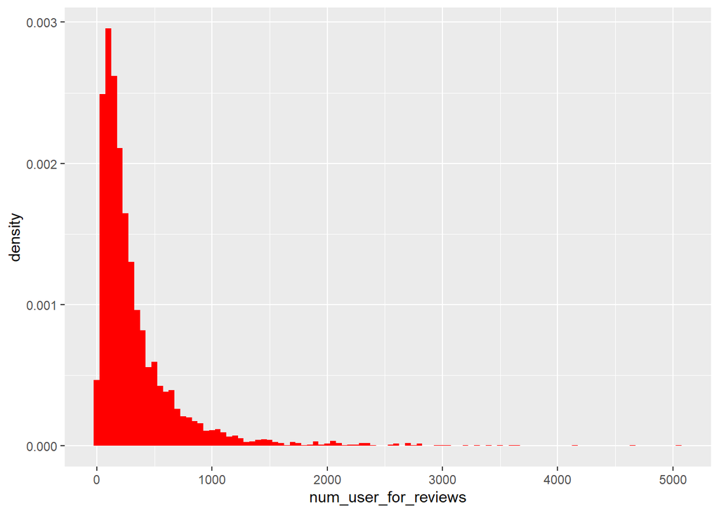

```r
ggplot(movies,aes(x=num_user_for_reviews))+
  geom_histogram(binwidth=50,aes(y=..density..),fill="red")
```

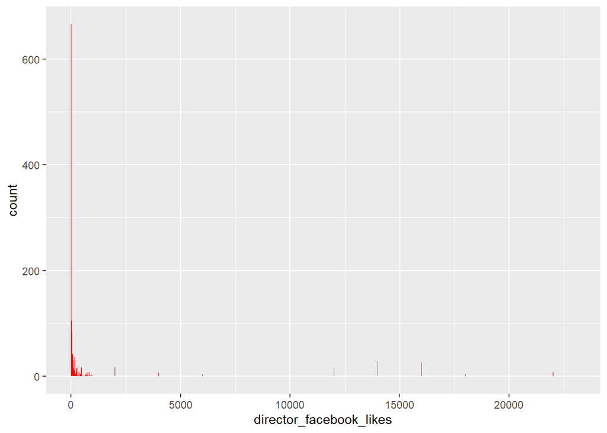

```r
ggplot(movies,aes(x=director_facebook_likes))+
  geom_histogram(binwidth=5,aes(y=..count..),fill="red")
```

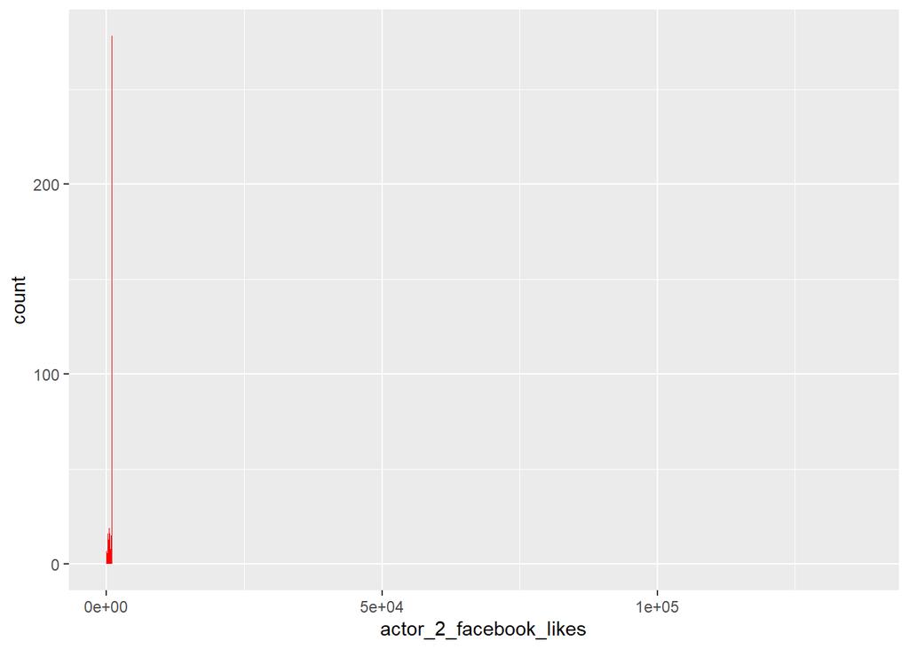

```r
ggplot(movies,aes(x=actor_2_facebook_likes))+
  geom_histogram(binwidth=5,aes(y=..count..),fill="red")
```

[figure not shown]

```r
ggplot(movies,aes(x=actor_1_facebook_likes))+
  geom_histogram(binwidth=5,aes(y=..count..),fill="red")
```

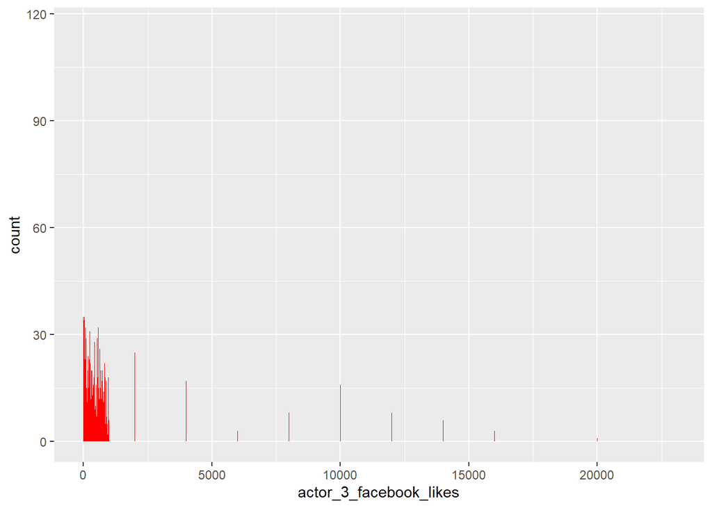

```r
ggplot(movies,aes(x=actor_3_facebook_likes))+
  geom_histogram(binwidth=5,aes(y=..count..),fill="red")
```

**Bivariate analysis** *Top 10 Director with most movies*

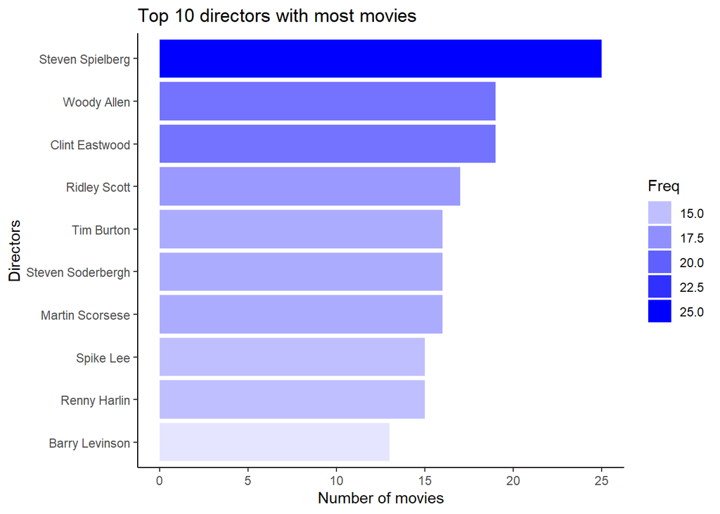

```r
directors <- as.data.frame(table(movies$director_name))
directors <- arrange(directors, desc(Freq))
ggplot(head(directors, 10), aes(x = reorder(factor(Var1), Freq), y = Freq, alpha = Freq)) +
  geom_bar(stat = "identity", fill = "blue") +
  labs(x = "Directors", y = "Number of movies") +
  ggtitle("Top 10 directors with most movies") +
  coord_flip() +
  theme_classic()
```

*Top 10 Directors with highest average IMDB movies*

```r
movies%>%
  group_by(director_name) %>%
  summarise(Highest_avg_imdb_score = mean(imdb_score)) %>%
  arrange(desc(Highest_avg_imdb_score)) %>%
  top_n(10, Highest_avg_imdb_score) %>%
  formattable(list(Highest_avg_imdb_score = color_bar("orange")), align = 'l')
```

| director_name | Highest_avg_imdb_score |
| --- | --- |
| Akira Kurosawa | 8.70 |
| Charles Chaplin | 8.60 |
| Tony Kaye | 8.60 |
| Alfred Hitchcock | 8.50 |
| Damien Chazelle | 8.50 |
| Majid Majidi | 8.50 |
| Ron Fricke | 8.50 |
| Sergio Leone | 8.43 |
| Christopher Nolan | 8.43 |
| Asghar Farhadi | 8.40 |
| Richard Marquand | 8.40 |

**Top 10 Actors with most movies**

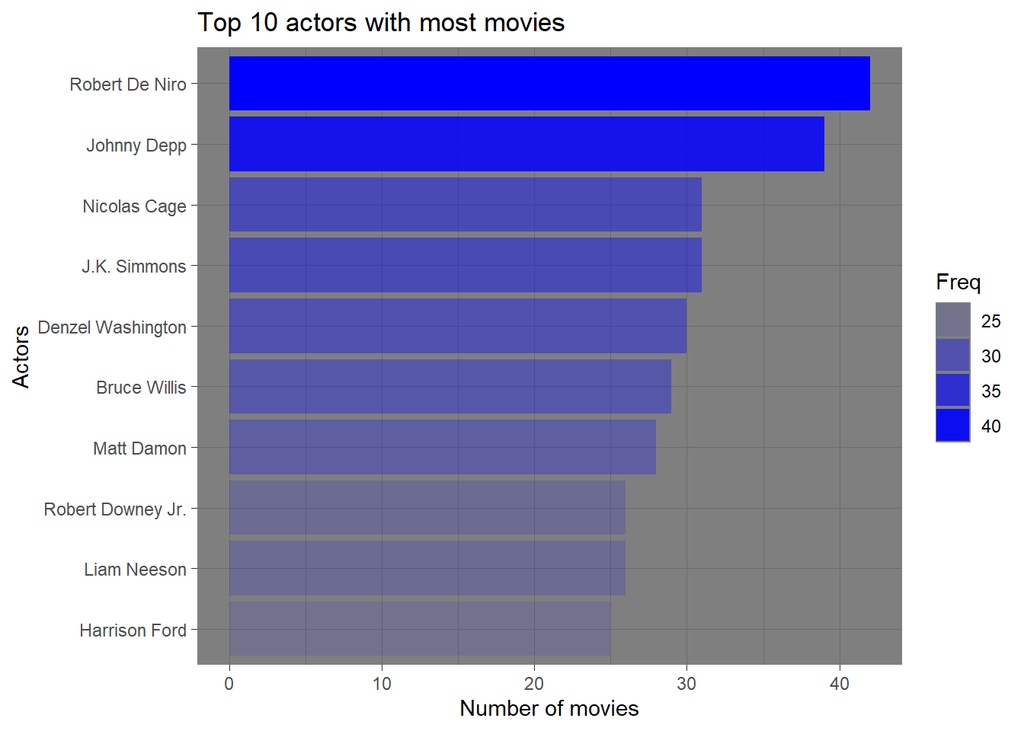

```r
actors <- as.data.frame(table(movies$actor_1_name))
actors <- arrange(actors, desc(Freq))
ggplot(head(actors, 10), aes(x = reorder(factor(Var1), Freq), y = Freq, alpha = Freq)) +
  geom_bar(stat = "identity", fill = "blue") +
  labs(x = "Actors", y = "Number of movies") +
  ggtitle("Top 10 actors with most movies") +
  coord_flip() +
  theme_dark()
```

**Top 10 Actors with highest average IMDB movies**

```r
movies%>%
  group_by(actor_1_name) %>%
  summarise(Highest_avg_imdb_score = mean(imdb_score)) %>%
  arrange(desc(Highest_avg_imdb_score)) %>%
  top_n(10, Highest_avg_imdb_score) %>%
  formattable(list(Highest_avg_imdb_score = color_bar("orange")), align = 'l')
```

| actor_1_name | Highest_avg_imdb_score |
| --- | --- |
| Scatman Crothers | 8.7 |
| Takashi Shimura | 8.7 |
| Bunta Sugawara | 8.6 |
| Paulette Goddard | 8.6 |
| Bahare Seddiqi | 8.5 |
| Collin Alfredo St. Dic | 8.5 |
| Emilia Fox | 8.5 |
| Janet Leigh | 8.5 |
| Claude Rains | 8.4 |
| Jürgen Prochnow | 8.4 |
| Mathieu Kassovitz | 8.4 |
| Mhairi Calvey | 8.4 |
| Shahab Hosseini | 8.4 |

**Actor2**

```r
movies%>%
  group_by(actor_2_name) %>%
  summarise(Highest_avg_imdb_score = mean(imdb_score)) %>%
  arrange(desc(Highest_avg_imdb_score)) %>%
  top_n(10, Highest_avg_imdb_score) %>%
  formattable(list(Highest_avg_imdb_score = color_bar("orange")), align = 'l')
```

| actor_2_name | Highest_avg_imdb_score |
| --- | --- |
| Jeffrey DeMunn | 8.9 |
| Luigi Pistilli | 8.9 |
| Kenny Baker | 8.8 |
| Marcus Chong | 8.7 |
| Michael Berryman | 8.7 |
| Minoru Chiaki | 8.7 |
| Peter Cushing | 8.7 |
| Seu Jorge | 8.7 |
| Ryûnosuke Kamiki | 8.6 |
| Stanley Blystone | 8.6 |

**Actor3**

```r
movies%>%
  group_by(actor_3_name) %>%
  summarise(Highest_avg_imdb_score = mean(imdb_score)) %>%
  arrange(desc(Highest_avg_imdb_score)) %>%
  top_n(10, Highest_avg_imdb_score) %>%
  formattable(list(Highest_avg_imdb_score = color_bar("orange")), align = 'l')
```

| actor_3_name | Highest_avg_imdb_score |
| --- | --- |
| Caroline Goodall | 8.90 |
| Enzo Petito | 8.90 |
| Phil LaMarr | 8.90 |
| Anthony Daniels | 8.80 |
| Eugenie Bondurant | 8.80 |
| Sam Anderson | 8.80 |
| Billy Boyd | 8.75 |
| Alexandre Rodrigues | 8.70 |
| Gloria Foster | 8.70 |
| Kamatari Fujiwara | 8.70 |
| Louise Fletcher | 8.70 |

**Distribution of Movies of different countries.**

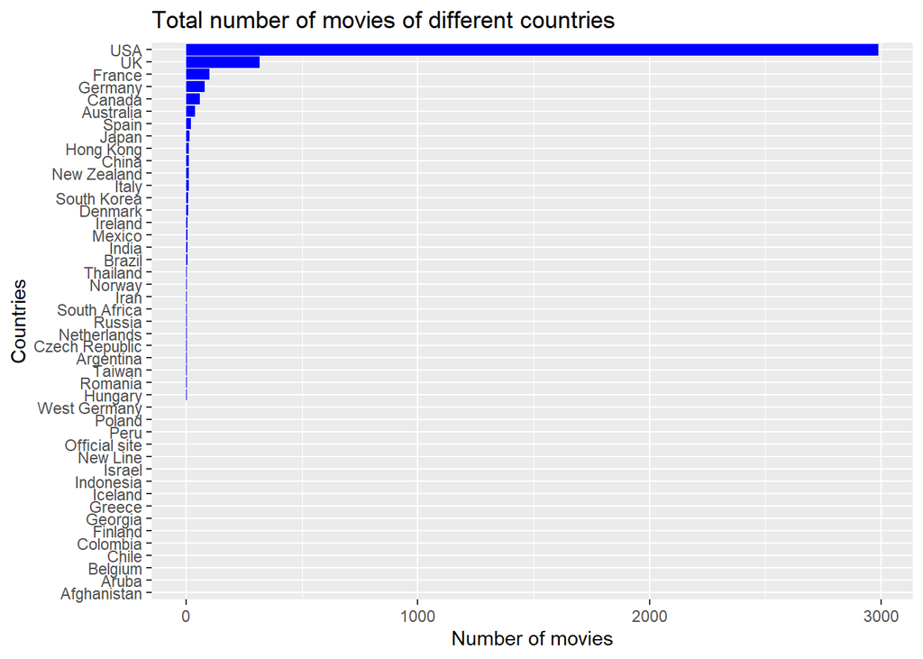

```r
country <- as.data.frame(table(movies$country))
ggplot(country, aes(x = reorder(factor(Var1), Freq), y = Freq)) +
  geom_bar(stat = "identity", fill = "blue") +
  labs(x = "Countries", y = "Number of movies") +
  ggtitle("Total number of movies of different countries") +
  coord_flip() +
  theme_get()
```

**Distribution of Movies year wise.**

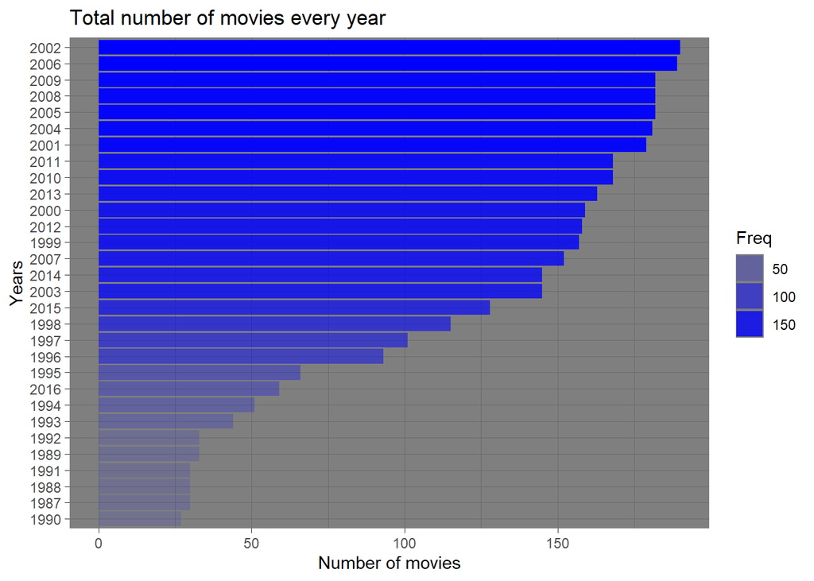

```r
#Number of movies was high after the year 2000.
year <- as.data.frame(table(movies$title_year))
year <- arrange(year, desc(Freq))
ggplot(year[1:30,], aes(x = reorder(factor(Var1), Freq), y = Freq, alpha = Freq))+
  geom_bar(stat = "identity", fill = "blue") +
  labs(x = "Years", y = "Number of movies") +
  ggtitle("Total number of movies every year") +
  coord_flip() +
  theme_dark()
```

**Ratings given to movies.**

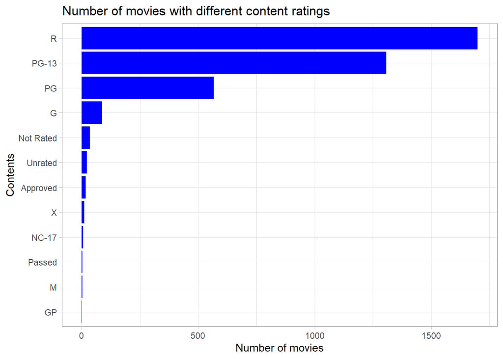

```r
rating <- as.data.frame(table(movies$content_rating))
rating <- arrange(rating, desc(Freq))
ggplot(rating, aes(x = reorder(factor(Var1), Freq), y = Freq)) +
  geom_bar(stat = "identity", fill = "blue") +
  labs(x = "Contents", y = "Number of movies") +
  ggtitle("Number of movies with different content ratings") +
  coord_flip() +
  theme_light()
```

#Did the number of users voted for the movie has impact on imdb score ?

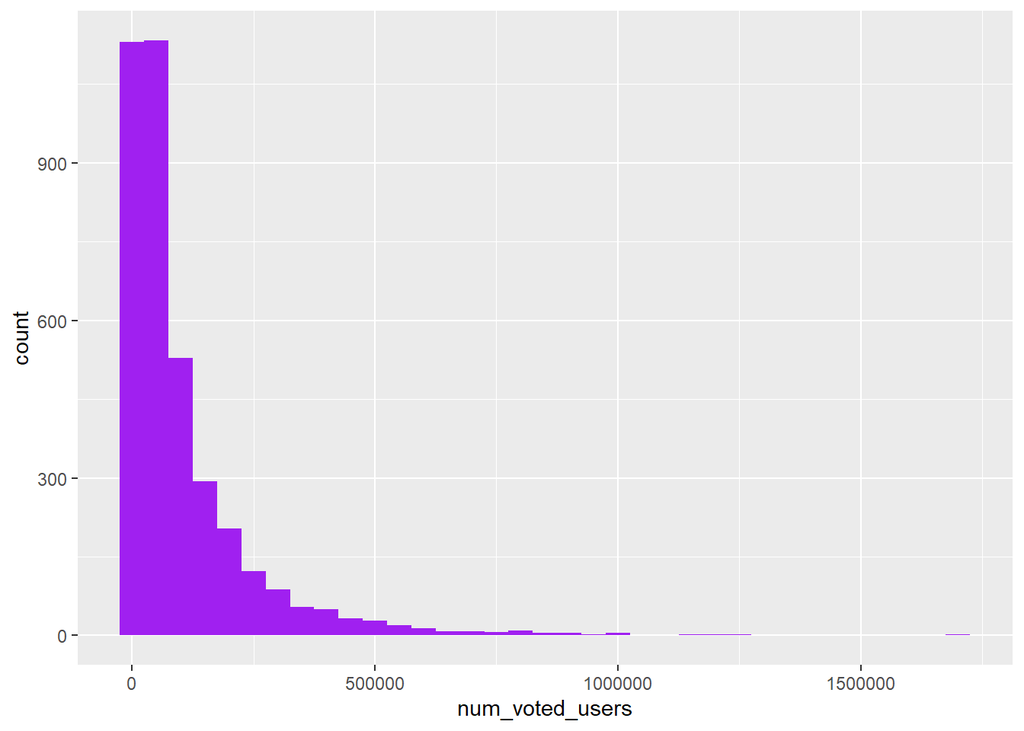

```r
ggplot(movies,aes(x=num_voted_users))+geom_histogram(binwidth=50000,fill="purple")
```

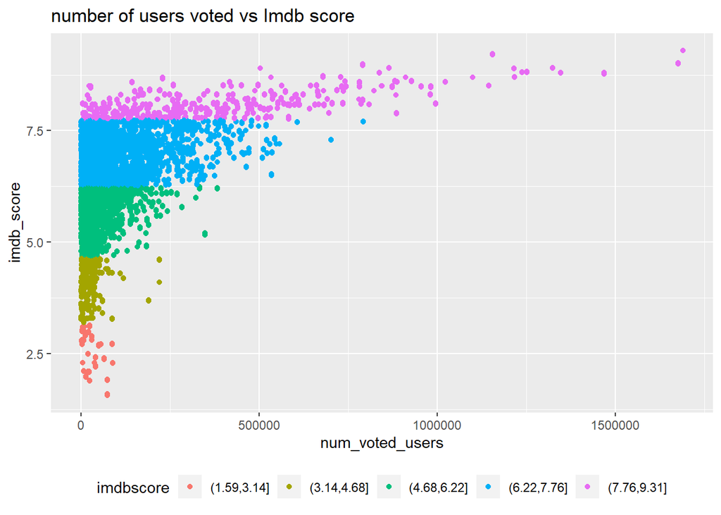

```r
movies %>%
  select(movie_title,num_voted_users,imdb_score)%>%
  arrange(desc(num_voted_users))%>%
  ggplot(aes(x=num_voted_users,y=imdb_score,col=cut(imdb_score,5)))+
  geom_point()+
  geom_jitter()+
  labs(title="number of users voted vs Imdb score",col="imdbscore")+
  theme(legend.position = "bottom")
```

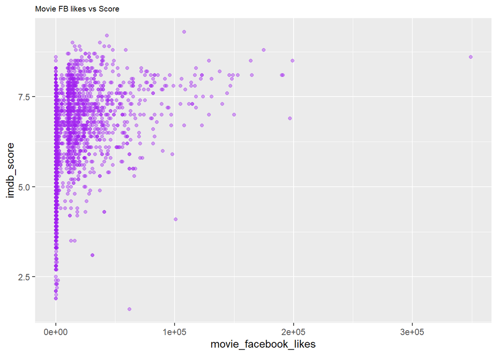

```r
movies %>%
  ggplot(aes(x=movie_facebook_likes,y=imdb_score))+
  geom_point(color="purple",alpha=0.4)+
  theme(legend.position="bottom",plot.title = element_text(size=8))+
  labs(title="Movie FB likes vs Score")
```

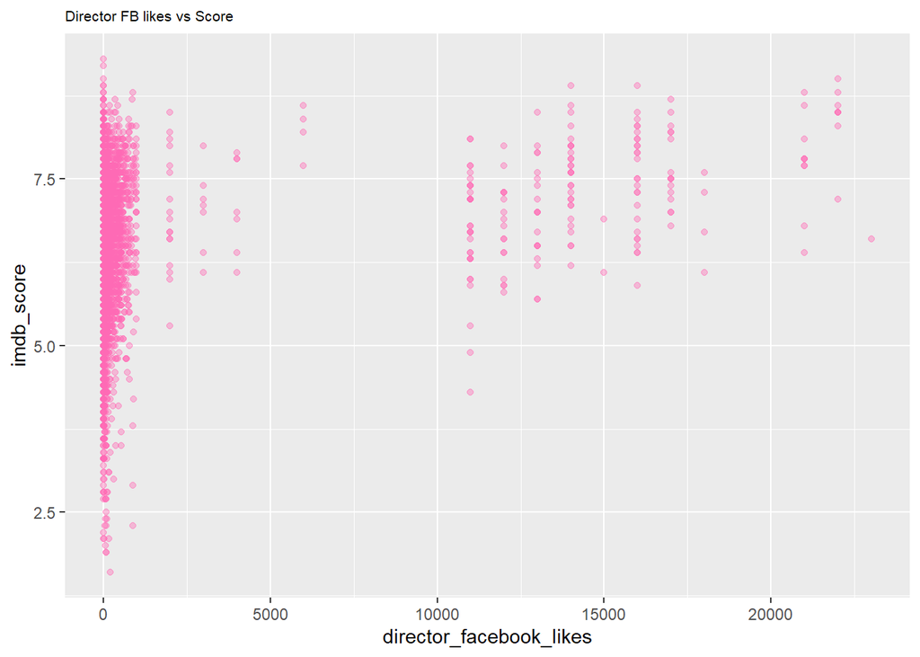

```r
movies %>%
  ggplot(aes(x=director_facebook_likes,y=imdb_score))+
  geom_point(color="hotpink",alpha=0.4)+
  theme(legend.position="bottom",plot.title = element_text(size=8))+
  labs(title="Director FB likes vs Score")
```

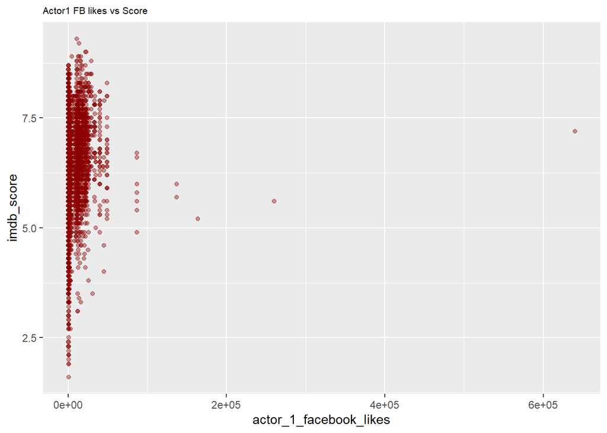

```r
movies %>%
  ggplot(aes(x=actor_1_facebook_likes,y=imdb_score))+
  geom_point(color="red4",alpha=0.4)+
  theme(legend.position="bottom",plot.title = element_text(size=8))+
  labs(title="Actor1 FB likes vs Score")
```

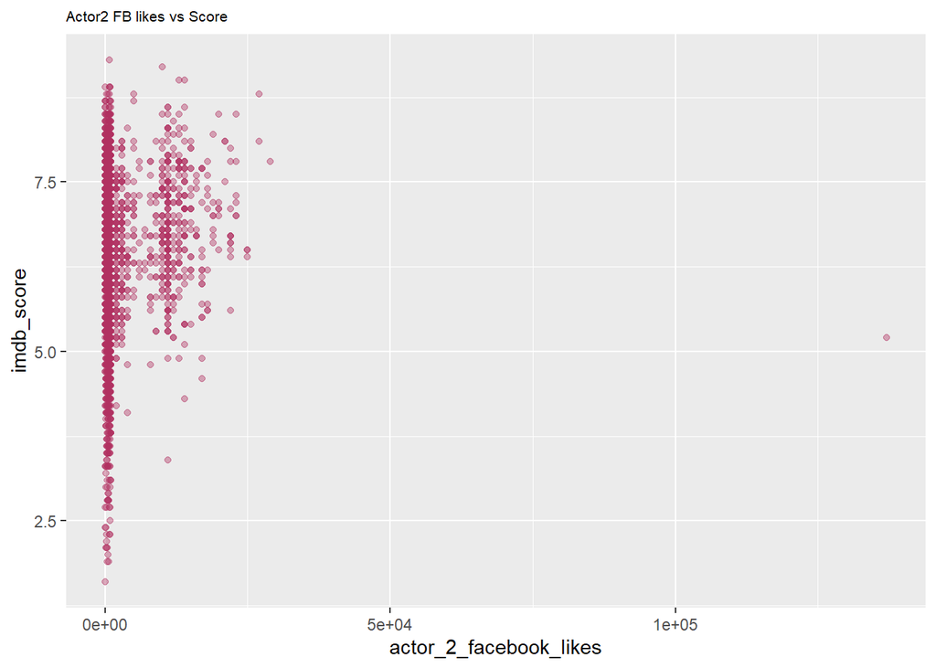

```r
movies %>%
  ggplot(aes(x=actor_2_facebook_likes,y=imdb_score))+
  geom_point(color="maroon",alpha=0.4)+
  theme(legend.position="bottom",plot.title = element_text(size=8))+
  labs(title="Actor2 FB likes vs Score")
```

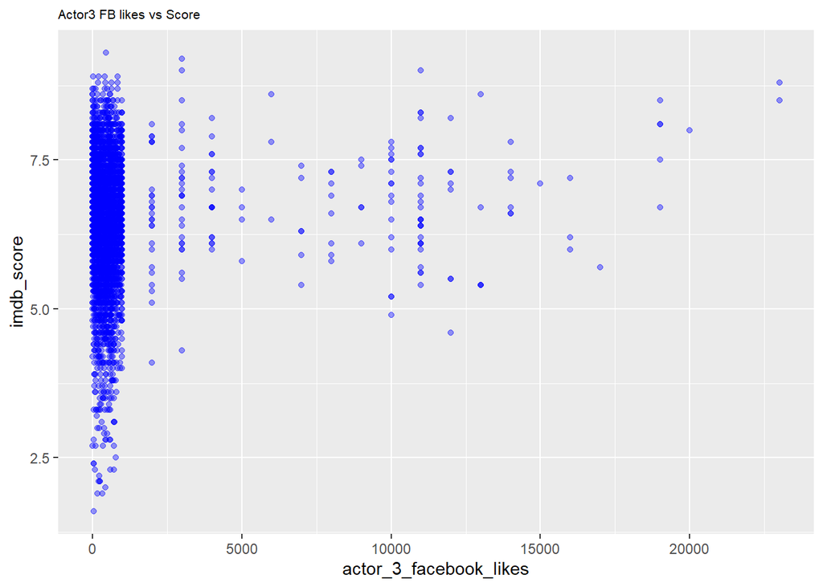

```r
movies %>%
  ggplot(aes(x=actor_3_facebook_likes,y=imdb_score))+
  geom_point(color="blue",alpha=0.4)+
  theme(legend.position="bottom",plot.title = element_text(size=8))+
  labs(title="Actor3 FB likes vs Score")
```

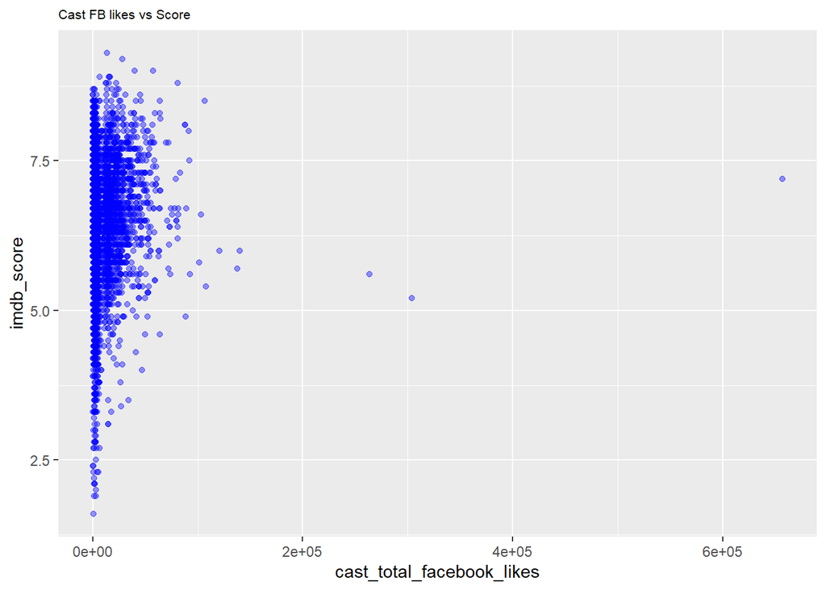

```r
movies %>%
  ggplot(aes(x=cast_total_facebook_likes,y=imdb_score))+
  geom_point(color="blue",alpha=0.4)+
  theme(legend.position="bottom",plot.title = element_text(size=8))+
  labs(title="Cast FB likes vs Score")
```